# Assessment

01 December, 2025

# **Exploring the pattern of prescription of Monoamine oxidase inhibitors**

Monoamine oxidase inhibitors (MAOIs) are a class of antidepressant medications. They work by blocking the enzyme monoamine oxidase from breaking down brain neurotransmitters (norepinephrine, serotonin, dopamine, and tyramine), thus increasing their levels and influence on cells (Laban and Saadabadi, 2023). MAOIs are now rarely used as their prescribing is complex, with issues surrounding toxicity in overdose, drug-drug as well as food interactions. This means they are largely reserved for specialist prescriptions and are only used for treatment-resistant depression, when more straightforward options have shown little effect (Chamberlain et al., 2020).

This work explores pattern of MAOIs prescribing in different health boards as well as individual GP surgeries. As these are specialist medications, it’s safe to assume that they are only initiated in secondary and tertiary care with GPs participating in shared care agreements. The aforementioned fact makes them suitable for exploring:

- the number of prescriptions is likely to be lower, hence a clearer pattern or outliers might emerge;
- their prescription will also indicate a more serious disease, potentially, allowing more clear relationship patterns between broader socio-economic factors and mental health ilness to emerge.

#### The working hypothesis is that there is some association between MAOIs prescription numbers and GP surgeries located in more deprived areas.

```r
# This section loads the necessary libraries

library(tidyverse)
library(janitor) # cleaning data
library(gt) # tables
library(here) # directory structure
library(scales) #nice wrapping of labels on graphs
library(ggpubr) #combining multiple plots together
```

```r
# This section creates the necessary functions

#Function to create the graph of the relationship between x, passed into function, and prescription numbers per 1000 people; the labels are adapted for the situation where x is a name of a healthboard

create_plot_per_pop <- function(data, x, healthboard_name) {
    result <- data %>%
      filter(hb_name == {healthboard_name}) %>%
      ggplot(aes(x = fct_rev(fct_reorder({{x}}, quantity_per_thousand)), y = quantity_per_thousand)) +
      geom_col(fill = "#e2bf8a") +
      theme_light()+
      scale_x_discrete(labels = label_wrap(8))+
      labs(title = paste("Prescription of MAOIs per 1000 people in each GP surgery in", healthboard_name),
       x = "GP surgery name",
       y = "MOAI quantity per 1000 people")
}
```

Four reference datasets have been selected from <www.opendata.nhs.scot> :

- Health board number and name reference “book”;
- Addresses and practice list size of Scottish GP surgeries (including datazone) for July 2025 (to align with the prescription dataset chosen: GP dataset is available for October, July, April and January 2025, however, prescription dataset only goes up to August 2025, making July the most up-to-date match);
- Heath board population projections dataset, using the information for 2025 in order to keep it as up-to-date as possible;
- Scottish Index of Multiple Deprivation (Population Weighted) dataset (including the overall rating most deprived to least deprived).

```r
# This section loads the necessary datasets, selecting only the colums that are relevant in order not to store unnecessary information

#Loading Healthboard names and codes only as a reference dataset

HB_lookup <- read_csv("https://www.opendata.nhs.scot/dataset/9f942fdb-e59e-44f5-b534-d6e17229cc7b/resource/652ff726-e676-4a20-abda-435b98dd7bdc/download/hb14_hb19.csv") %>%
  clean_names() %>%
  select(hb, hb_name)

#Loading GP practices details (including data zones)

gp_addresses <- read_csv("https://www.opendata.nhs.scot/dataset/f23655c3-6e23-4103-a511-a80d998adb90/resource/30b06220-17ad-44e8-b6c5-658d41ec1ea5/download/practice_contactdetails_jul2025-open-data.csv") %>%
  clean_names() %>%
  select(practice_code:practice_list_size, postcode, hb, data_zone)

#Loading Health board population details (to be able to use projections for the relevant year - 2025)

hb_populations <- read_csv("https://www.opendata.nhs.scot/dataset/9e00b589-817e-45e6-b615-46c935bbace0/resource/0876fc67-05e6-4e87-bc30-c4b0756fff04/download/hb_pop_proj_01102025.csv") %>%
  clean_names() %>%
  filter(year == "2025") %>%
  select(year, hb, sex, all_ages)

#Loading Scottish index of multiple deprivation data

simd <- read_csv("https://www.opendata.nhs.scot/dataset/78d41fa9-1a62-4f7b-9edb-3e8522a93378/resource/acade396-8430-4b34-895a-b3e757fa346e/download/simd2020v2_22062020.csv") %>%
  clean_names() %>%
  select(data_zone, hb, simd2020v2rank, simd2020v2country_decile, simd2020v2most15pc, simd2020v2least15pc)
```

The first step would be to have a look at a general pattern of MAOIs prescriptions in different health boards. There might be some expectation that bigger health boards with big secondary and tertiary care teams and hospitals might be prescribing more MOAIs due to greater capacity to do so (e.g. Glagow and Clyde or Lothian).

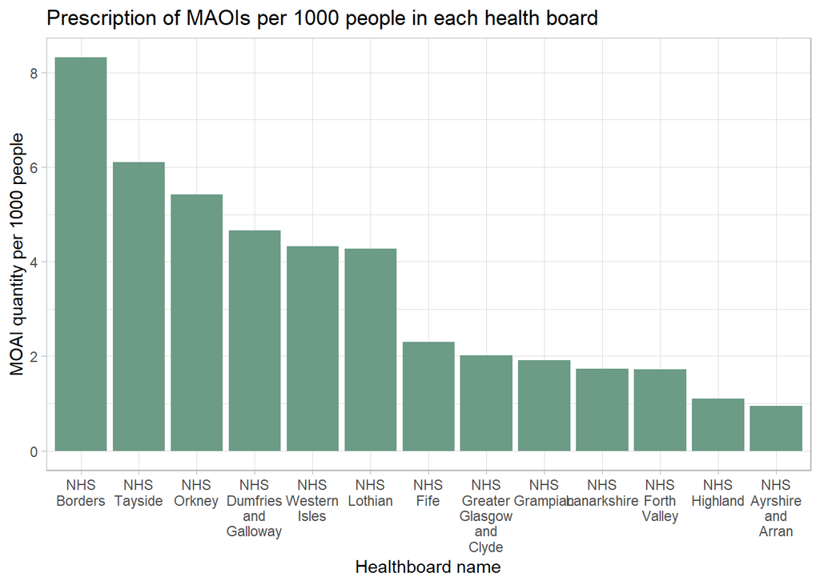

```r
# This section deals with the initial data exploration from July 2025 and rendering the first graph

#Creating a vector of the 4 MAOIs used in the UK (according to BNF)

maois <- c("TRANYLCYPROMINE", "PHENELZINE", "ISOCARBOXAZID", "MOCLOBEMIDE")

#Loading July 2025 GP prescriptions data, while sorting out the records relevant to MAOIs only

data_july_2025 <- read_csv("https://www.opendata.nhs.scot/dataset/84393984-14e9-4b0d-a797-b288db64d088/resource/12448904-f11c-4a0f-8dab-8b47c5abebf8/download/pitc202507.csv") %>%
  clean_names() %>%
  filter(str_detect(bnf_item_description, paste(maois, collapse = "|"))) %>%
  select(hbt, gp_practice, bnf_item_description, paid_quantity)

#Joining the healthboard names to the MAOIs dataset and filtering out the columns of interest

data_july_2025 <- data_july_2025 %>%
  left_join(HB_lookup, join_by(hbt == hb)) %>%
  select(hb_name, hbt : paid_quantity)

#Collapsing the data so that all MAOIs are combined (worth noting that PHENELZINE isn't present at all, however, given the complexity of MAOIs prescribing, there might be many different reasons for this ) for Health boards

maoi_data_hb <- data_july_2025 %>%
  group_by(hb_name, hbt) %>%
  summarise(drug_quantity = sum(paid_quantity))

#Adding the population data for healthboards, creating a new column of quantity per thousand of people. this is necessary to be able to compare different healthboards, given their vastly different population numbers

maoi_data_hb <- hb_populations %>%
  right_join(maoi_data_hb, join_by(hb == hbt)) %>%
  filter(sex == "All") %>%
  select(hb_name:drug_quantity, all_ages) %>%
  mutate(quantity_per_thousand = drug_quantity / all_ages * 1000)

#Creating a bar chart of the association between healthboard and the number of MAOI prescriptions per 1000 people arranged in descending order

maoi_data_hb %>%
  ggplot(aes(x = fct_rev(fct_reorder(hb_name, quantity_per_thousand)), y = quantity_per_thousand, )) +
  geom_col(fill = "#6c9b86") +
  scale_x_discrete(labels = label_wrap(8)) +
  theme_light()+
  labs(title = "Prescription of MAOIs per 1000 people in each health board",
       x = "Healthboard name",
       y = "MOAI quantity per 1000 people")
```

Contrary to initial hypothesis, the biggest prescribers are smaller healthboards. The two most interesting observations here are:

- NHS Borders (3rd smallest healthboard) prescribes 30% more MAOIs than NHS Tayside, almost double of the amount of NHS Lothian and four times the amount of NHS Greater Glasgow and Clyde;
- NHS Orkney (the smallest healthboard with no psychiatric hospital) is the third largest prescriber.

This might indicate that it is the lack of secondary and tertiary services rather than their presence that drives MAOIs prescriptions. Although then NHS Lothian and Greater Glasgow and Clyde would be expected to be the smallest prescribers. It’s worth noting, however, that the size of healthboard is not equivalent to the real-life usable resources it has, the populations used are projections and, given MAOIs require a specific skill set and training, it could also be due to individual senior consultants preferences.

To investigate the data further, it’s possible to look at the prescriptions by individual GPs in each health board

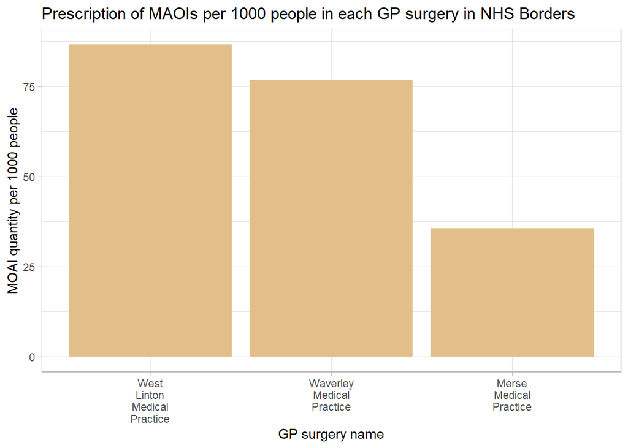

```r
#Collapsing the data so that all MAOIs are combined  for GP practices

maoi_data_gp <- data_july_2025 %>%
  group_by(hb_name, hbt, gp_practice) %>%
  summarise(drug_quantity = sum(paid_quantity))

#Adding the GP practice addresses and population size to summarised data

maoi_data_gp <- maoi_data_gp %>%
  left_join(gp_addresses, join_by(gp_practice == practice_code)) %>%
  select(-hb) %>%
  mutate(quantity_per_thousand = drug_quantity / practice_list_size * 1000)

#Creating a page of bar charts of the association between GP surgeries and the number of MAOI prescriptions per 1000 people grouped by Health boards using the previously defined function and an iterative "for" cycle

#Empty list to store individual graphs and healthboard names

gp_plots <- list()
labels_for_naming <- list()

#Setting i to 1, which will be used in the list array as an increment

i = 1

#The cycle function going through each healthboard in the dataframe, drawing and storing the graph of MAOIs prescriptions per 1000 population per GP surgery

  for (hb_name in unique(maoi_data_gp$hb_name)) {
    gp_plots[[i]] <- create_plot_per_pop(maoi_data_gp, gp_practice_name, hb_name)
    labels_for_naming[[i]] <- hb_name
    i = i + 1
  }

#Incorporating healthboard names into the list

names(gp_plots) <- labels_for_naming

# Calling the GP breakdown graph for NHS Borders

gp_plots$`NHS Borders`
```

Surprisingly, there are only 3 surgeries there. The two possible hypotheses here can be:

- There are only 3 surgeries in the Borders (highly unlikely);
- These are the surgeries in most deprived areas dealing with a higher burden of unipolar depression (there is some evidence that deprivation can increase the likelihood of developing major depressive disorder (Remes et al., 2019); worth noting that it was only shown in men and the CI are fairly broad).

In order to test both of these assumptions a new dataset with all the surgeries within the Health board needs to be created

```r
#Creating a dataset with all the GP surgeries (even those with 0 prescriptions of interest)

#Joining the healthboards to the dataset first

gp_addresses_and_hbs <- gp_addresses %>%
  left_join(HB_lookup, join_by(hb)) %>%
  rename(hbt = hb) %>%
  select(hb_name, hbt, practice_code : data_zone)

#Creating the actual dataset

maoi_data_all_gps <- maoi_data_gp %>%
  ungroup() %>%
  select(gp_practice:drug_quantity, quantity_per_thousand) %>%
  right_join(gp_addresses_and_hbs, join_by(gp_practice == practice_code)) %>%
  select(hb_name, hbt, gp_practice : data_zone) %>%
  mutate(drug_quantity = ifelse(is.na(drug_quantity), 0, drug_quantity), quantity_per_thousand = ifelse(is.na(quantity_per_thousand), 0, quantity_per_thousand))


#Adding the deprivation dataset to gp summarised data

maoi_data_all_gps <- maoi_data_all_gps %>%
  left_join(simd, join_by(data_zone)) %>%
  select(hb_name : data_zone, simd2020v2rank, simd2020v2country_decile, simd2020v2most15pc, simd2020v2least15pc)

# Creating the table to show the data of interest sorting it out by the absolute deprivation ranking (most deprived to least deprived)

borders_outliers_by_deprivation <- maoi_data_all_gps %>%
  filter(hb_name == "NHS Borders") %>%
  select(hb_name, gp_practice_name: postcode, quantity_per_thousand, simd2020v2rank) %>%
  arrange(simd2020v2rank) %>%
  gt() %>%
# Rename the columns to make them more user friendly
  cols_label(hb_name = "Health Board",
            gp_practice_name = "GP Practice",
            practice_list_size = "Patient number",
            postcode = "Postcode",
            quantity_per_thousand = "Prescriptions per thousand",
            simd2020v2rank = "Scottish Index of Multiple Deprivation ranking") %>%

  # Format the columns with numbers to have zero decimal places
  fmt_number(decimals = 0) %>%

  # Centre the number columns

  cols_align(align = "center") %>%

  # Add a title and subtitle
   tab_header(
       title = "GP surgeries ranked by deprivation, most to least") %>%
  # Add alternating colouring to the table rows
  opt_stylize(style = 6, color = "cyan", add_row_striping = TRUE)

borders_outliers_by_deprivation
```

GP surgeries ranked by deprivation, most to least

| Health Board | GP Practice | Patient number | Postcode | Prescriptions per thousand | Scottish Index of Multiple Deprivation ranking |
| --- | --- | --- | --- | --- | --- |
| NHS Borders | Mairches Medical Practice Hawick | 5,769 | TD9 9HU | 0 | 1,233 |
| NHS Borders | Roxburgh Street Surgery | 3,698 | TD1 1PF | 0 | 1,696 |
| NHS Borders | Kelso Medical Group | 11,992 | TD5 7LF | 0 | 1,868 |
| NHS Borders | Teviot Medical Practice | 11,886 | TD9 9DT | 0 | 2,215 |
| NHS Borders | Eyemouth Medical Practice | 6,780 | TD14 5DD | 0 | 2,312 |
| NHS Borders | Eildon Surgery | 6,997 | TD6 0PP | 0 | 2,966 |
| NHS Borders | Greenlaw Surgery | 1,463 | TD10 6XJ | 0 | 3,057 |
| NHS Borders | Selkirk Medical Practice | 7,307 | TD7 4LJ | 0 | 3,618 |
| NHS Borders | The Neidpath Practice | 5,946 | EH45 8JG | 0 | 3,631 |
| NHS Borders | The Tweed Practice | 6,013 | EH45 8JG | 0 | 3,631 |
| NHS Borders | Newcastleton Medical Practice | 1,599 | TD9 0RU | 0 | 3,765 |
| NHS Borders | Merse Medical Practice | 6,301 | TD11 3EL | 36 | 3,950 |
| NHS Borders | Duns Medical Group | 3,283 | TD11 3EL | 0 | 3,950 |
| NHS Borders | Coldstream Medical Practice | 3,918 | TD12 4LQ | 0 | 3,961 |
| NHS Borders | St Ronan's Practice | 4,790 | EH44 6QE | 0 | 4,228 |
| NHS Borders | Waverley Medical Practice | 5,471 | TD1 2UA | 77 | 4,603 |
| NHS Borders | Braeside Medical Practice | 4,628 | TD1 2UA | 0 | 4,603 |
| NHS Borders | Mairches Medical Practice Galashiels | 5,051 | TD1 2UA | 0 | 4,603 |
| NHS Borders | Jedburgh Medical Practice | 6,836 | TD8 6EN | 0 | 4,847 |
| NHS Borders | Stow & Lauder Health | 4,665 | TD1 2SQ | 0 | 4,872 |
| NHS Borders | Earlston Medical Practice | 3,483 | TD4 6DW | 0 | 5,466 |
| NHS Borders | West Linton Medical Practice | 3,879 | EH46 7EX | 87 | 5,670 |

It’s fairly clear here that there is no obvious asociation between deprivation ranking and number of MAOIs prescriptions, with the surgery prescribing the most also covering the least deprived area.

A similar exploration can be done for NHS Orkney.

```r
# Creating the table to show the data of interest sorting it out by the absolute deprivation ranking (most deprived to least deprived)

orkney_outliers_by_deprivation <- maoi_data_all_gps %>%
  filter(hb_name == "NHS Orkney") %>%
  select(hb_name, gp_practice_name: postcode, quantity_per_thousand, simd2020v2rank) %>%
  arrange(simd2020v2rank) %>%
  gt() %>%
  # Rename the columns to make them more user friendly
  cols_label(hb_name = "Health Board",
            gp_practice_name = "GP Practice",
            practice_list_size = "Patient number",
            postcode = "Postcode",
            quantity_per_thousand = "Prescriptions per thousand",
            simd2020v2rank = "Scottish Index of Multiple Deprivation ranking") %>%

  # Format the columns with numbers to have zero decimal places
  fmt_number(decimals = 0) %>%

  # Centre the number columns

  cols_align(align = "center") %>%

  # Add a title and subtitle
   tab_header(
       title = "GP surgeries ranked by deprivation, most to least") %>%
  # Add alternating colouring to the table rows
  opt_stylize(style = 6, color = "blue", add_row_striping = TRUE)
```

Looking at the table, surprisingly, only one surgery. The same two hypotheses as for NHS Borders can be explored.

```r
orkney_outliers_by_deprivation
```

GP surgeries ranked by deprivation, most to least

| Health Board | GP Practice | Patient number | Postcode | Prescriptions per thousand | Scottish Index of Multiple Deprivation ranking |
| --- | --- | --- | --- | --- | --- |
| NHS Orkney | Islands View Surgery | 249 | KW17 2PU | 0 | 2,710 |
| NHS Orkney | Daisy Villa | 1,508 | KW17 2SN | 0 | 3,421 |
| NHS Orkney | Skerryvore Practice | 8,717 | KW15 1NZ | 14 | 4,836 |
| NHS Orkney | Heilendi Practice | 3,962 | KW15 1NZ | 0 | 4,836 |
| NHS Orkney | Orcades Practice | 1,949 | KW15 1NZ | 0 | 4,836 |
| NHS Orkney | Dounby Surgery | 2,828 | KW17 2HH | 0 | 5,424 |
| NHS Orkney | Stromness Surgery | 3,090 | KW16 3AD | 0 | 5,566 |

And, like before, no clear association. The only surgery prescribing MAOIs (at quite huge numbers per thousand) is in the third least deprived area.

In conclusion, while none of the explored associations have shown clear-cut patterns, some interesting prescribing practices have been noticed. The next steps could be exploring the remaining graph dataset (list) for other healthbords and then moving towards exploring those patterns in the context of more than one month (e.g. a year). It would also be quite useful and interesting to look at these prescribing practices in more detail, potentially, accessing clinical data. Because the question why only one out of seven (NHS Orkney) and three out twenty-two (NHS Borders) prescribe MAOIs remains.

## **Reference list**

Chamberlain , S.R., Metastasio , A., Stokes , P.R.A., Baldwin, D.S., McAllister-Williams , H., Sinclair , J., Browning , M. and Young , A. (2020). POSITION STATEMENT PS03/20 Use of monoamine oxidase inhibitors (MAOIs) in psychiatric practice. [online] Royal College of Psychiatrists. Available at: https://www.rcpsych.ac.uk/docs/default-source/improving-care/better-mh-policy/position-statements/ps03_20.pdf?sfvrsn=bc814c70_2 [Accessed 30 Nov. 2025].

Laban, T.S. and Saadabadi, A. (2023). Monoamine Oxidase Inhibitors (MAOI). [online] Nih.gov. Available at: https://www.ncbi.nlm.nih.gov/books/NBK539848/ [Accessed 30 Nov. 2025].

Remes, O., Lafortune, L., Wainwright, N., Surtees, P., Khaw, K.-T. and Brayne, C. (2019). Association between area deprivation and major depressive disorder in British men and women: a cohort study. BMJ Open, [online] 9(11), p.e027530. doi:https://doi.org/10.1136/bmjopen-2018-027530.